# SEACAR Coastal Wetlands Analysis

Last compiled on 29 June, 2022

# Important Notes

All scripts and outputs can be found on the SEACAR GitHub repository:

https://github.com/FloridaSEACAR/SEACAR_Panzik

This script is based off of code originally wrtten by Katie May Laumann

# Libraries and Settings

Loads libraries used in the script. Loads the Segoe UI font for use in the figures. The inclusion of `scipen` option limits how frequently R defaults to scientific notation. Sets default settings for displaying warning and messages in created document, and sets figure dpi.

```r
library(knitr)
library(data.table)
library(dplyr)
library(lubridate)
library(ggplot2)
library(scales)
library(tidyr)
library(gridExtra)
library(tidyverse)
library(hrbrthemes)
windowsFonts(`Segoe UI` = windowsFont('Segoe UI'))
options(scipen=999)
opts_chunk$set(warning=FALSE, message=FALSE, dpi=200)
```

# File Import

Imports file that is determined in the SEACAR_CoastalWetlands_ReportRender.R script.

The script then gets the name of the parameter as it appears in the data file and units of the parameter.

```r
wetlands <- read.csv(file_in)
colnames(wetlands)
```

```
##  [1] "RowID"                                            "ProgramID"
##  [3] "ProgramName"                                      "ProgramLocationID"
##  [5] "QuadIdentifier"                                   "CommonIdentifier"
##  [7] "SpeciesName"                                      "GenusName"
##  [9] "SpeciesGroup1"                                    "SpeciesGroup2"
## [11] "CLC_Num"                                          "LC_Name"
## [13] "SampleDate"                                       "Transect_M"
## [15] "QuadSize_m2"                                      "ManagedArea"
## [17] "Region"                                           "CHIMMP"
## [19] "Year"                                             "Month"
## [21] "DataFileName"                                     "MADup"
## [23] "X.PercentCover.SpeciesComposition_.."             "X.StemDensity_..m2."
## [25] "X.Total.CanopyPercentCover.SpeciesComposition_.." "X.BasalArea_m2.ha."
```

# Data Filtering

The processing and filtering that is done to the data is as follows:

```r
#colnames(wetlands) [23]<-"perccov"
colnames(wetlands)[colnames(wetlands) == "X.PercentCover.SpeciesComposition_.."] <- "perccov"

#remove NAs from Genus and Species. This is for spp level analysis.
#*****can do this for group level analysis, but don't need to. All genus NA's are also NA in 'Group' columns
wetlands<-
  wetlands%>%
  filter(GenusName!="NA")

wetlands<-
  wetlands%>%
  filter(SpeciesName!="NA")

wetlands<-
  wetlands%>%
  filter(Month!="NA")

wetlands<-
  wetlands%>%
  filter(Year!="NA")

wetlands<-
  wetlands%>%
  filter(SpeciesGroup1!="NA")

wetlands<-
  wetlands%>%
  filter(SpeciesGroup1!="Invasive")

#You may decide to remove certain programs, for example here we remove
#program 5015, which only looks at a specific site, and program 651, at request of SMEs
wetlands<-
  wetlands%>%
  filter(ProgramID!="5015")

wetlands<-
  wetlands%>%
  filter(ProgramID!="651")


#remove duplicates and percent cover 0s
wetlands<-
 wetlands%>%
 filter(MADup==1)

wetlands<-
  wetlands%>%
  filter(perccov!=0)

#bring together Genus and species in one column so we have correct species names
wetlands$gensp<-paste(wetlands$GenusName, wetlands$SpeciesName, sep=" ")

wetlands$mth<-as.numeric(wetlands$Month)

wetlands$yr<-as.numeric(wetlands$Year)

#make a yearmonth column so we can analyze at that level
wetlands$yearmonth<-ifelse(wetlands$mth==10|wetlands$mth==11|wetlands$mth==12, (paste(wetlands$yr, wetlands$mth, sep=".")),
                           (paste(wetlands$yr, wetlands$mth, sep=".0")))

#correct misspellings in the dataset
wetlands$gensp2<-ifelse(wetlands$gensp=="Sarcocornia ambigua","Salicornia ambigua",paste(wetlands$gensp))
wetlands$gensp<-wetlands$gensp2

wetlands$SpeciesGroup1<-ifelse(wetlands$SpeciesGroup1=="Marsh succulents " ,"Marsh succulents",paste(wetlands$SpeciesGroup1))

#some Managed areas have the same spp counted by different programs in different years-this is not an issue for spp richness
#but will be important when we move on to % cover

wetlandsMA<-unique(wetlands[,c("Year","gensp","ManagedArea","yearmonth","Month","ProgramID")])

#remove program ID if you determine it does not sig impact spp rich
#How many Managed Areas do we have?
wetlandsMA<-
  wetlandsMA%>%
  filter(ManagedArea!="NA")

#remove Managed Areas that don't have at least 5 years of data.
##First, ID which ones have fewer than 5 yrs of data
nyearsMA<-
  wetlandsMA%>%
  group_by(ManagedArea)%>%
  summarise(length(unique(Year)))
colnames(nyearsMA) [2]<-"nyrsMA"

#Store names of Managed areas that have <5 years of data in the object "eliminateMA"
eliminateMA<-
  nyearsMA%>%
  filter(nyrsMA<5)

#eliminate those MAs from Analyses using antijoin
#use anti_join to include only programs>=5 yrs of data
wetlandsMA<-anti_join(wetlandsMA,eliminateMA,by=c("ManagedArea"))
```

# Species Richness

Gets species richness for each managed area. Uses piping from dplyr package to feed into subsequent steps. The following steps are performed:

1. Group data that have the same `ManagedAreaName`, `Year`, and `Month`.
2. Write species richness to a.csv file in the output directory
   - [Output Files in SEACAR GitHub](https://github.com/FloridaSEACAR/SEACAR_Panzik)

```r
wetlandsspprichReg<-
  wetlandsMA%>%
  group_by(ManagedArea,yearmonth,Year,Month)%>%
  summarise(length(unique(gensp)))

#"n" is the number of unique spp per Region and Year, aka the species Richness
##rename that column
colnames(wetlandsspprichReg) [5]<-"speciesrichness"
#what do we have?
wetlandsspprichReg
```

```
## # A tibble: 45 × 5
## # Groups:   ManagedArea, yearmonth, Year [45]
##    ManagedArea       yearmonth  Year Month speciesrichness
##    <chr>             <chr>     <int> <int>           <int>
##  1 Guana River Marsh 2012.11    2012    11               2
##  2 Guana River Marsh 2013.08    2013     8               2
##  3 Guana River Marsh 2014.01    2014     1               2
##  4 Guana River Marsh 2014.02    2014     2               3
##  5 Guana River Marsh 2014.03    2014     3               2
##  6 Guana River Marsh 2014.04    2014     4               2
##  7 Guana River Marsh 2014.05    2014     5               2
##  8 Guana River Marsh 2014.06    2014     6               2
##  9 Guana River Marsh 2014.07    2014     7               2
## 10 Guana River Marsh 2014.08    2014     8               2
## # … with 35 more rows
```

```r
#now we have richness
write.csv(wetlandsspprichReg,"output/wetlandsspprichReg.csv")
```

# Appendix I: Species Richness Plots

```r
#Plot species richness
plots_listyrmth <- lapply(unique(wetlandsspprichReg$ManagedArea), function (i) {

      dat <- filter(wetlandsspprichReg, ManagedArea == i)

      ggplot(data = dat, aes(x = yearmonth, y = speciesrichness)) +
            geom_point() +
            labs(title = i) +
            scale_x_discrete(breaks = wetlandsspprichReg$yearmonth[seq(1, length(wetlandsspprichReg$yearmonth), by = 1)])+
            theme(
                  axis.text.x = element_text(angle = 90, hjust = 1,size=6)
            )

})
plots_listyrmth
```

[[1]]

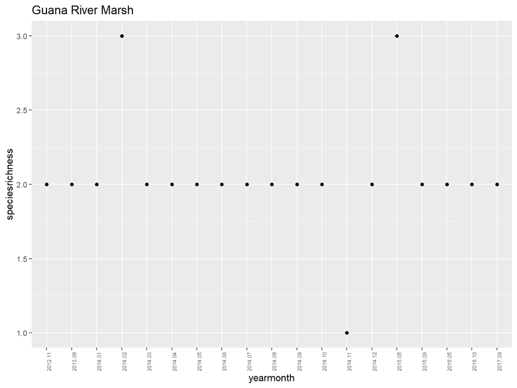

[[2]]

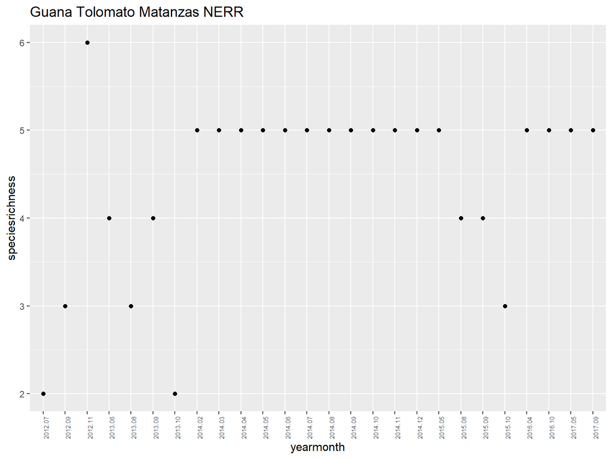

```r
#save as "Coastal Wetlands Species Richness by Year/Month"
png("output/Coastal Wetlands Species Richness by YearMonth, Managed Area.png")
print(plots_listyrmth)
```

[[1]]

[[2]]

```r
dev.off()
```

png 2

```r
#and for Year
plots_listyr <- lapply(unique(wetlandsspprichReg$ManagedArea), function (i) {

      dat <- filter(wetlandsspprichReg, ManagedArea == i)

      ggplot(data = dat, aes(x = Year, y = speciesrichness)) +
            geom_point() +
            labs(title = i) +
            scale_x_discrete(breaks = wetlandsspprichReg$Year[seq(1, length(wetlandsspprichReg$Year), by = 1)])+
            theme(
                  axis.text.x = element_text(angle = 90, hjust = 1,size=6)
            )

})
plots_listyr
```

[[1]]

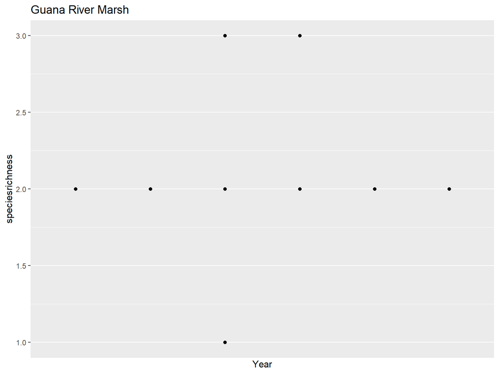

[[2]]

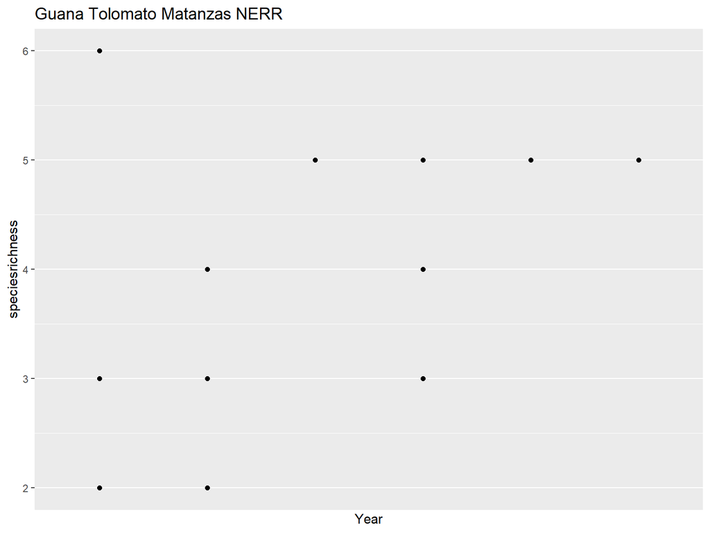

```r
png("output/Coastal Wetlands Species Richness by Year, Managed Area.png")
print(plots_listyr)
```

[[1]]

[[2]]

```r
dev.off()
```

png 2

```r
#RUN GLMs, one MA at a time
#start with just one Managed Area: GTMNERR
unique(wetlandsspprichReg$ManagedArea)
```

[1] “Guana River Marsh” “Guana Tolomato Matanzas NERR”

```r
GTMNERR<-
      wetlandsspprichReg%>%
      filter(ManagedArea=="Guana Tolomato Matanzas NERR")
colnames(GTMNERR)
```

[1] “ManagedArea” “yearmonth” “Year” “Month” “speciesrichness”

```r
#
#See if Month influences spp richness
GTMNERRMontheffect=glm(GTMNERR$speciesrichness~GTMNERR$Month)
summary(GTMNERRMontheffect)
```

Call: glm(formula = GTMNERR$speciesrichness ~ GTMNERR$Month)

Deviance Residuals: Min 1Q Median 3Q Max  
-2.4626 -0.3770 0.3663 0.6572 1.8113

Coefficients: Estimate Std. Error t value Pr(>|t|)  
(Intercept) 4.94178 0.61572 8.026 0.0000000298 *** GTMNERR$Month -0.06846 0.07676 -0.892 0.381  
— Signif. codes: 0 ‘**’ 0.001 ’**’ 0.01 ’’ 0.05 ‘.’ 0.1 ’ ’ 1

(Dispersion parameter for gaussian family taken to be 1.06254)

```
Null deviance: 26.346  on 25  degrees of freedom
```

Residual deviance: 25.501 on 24 degrees of freedom AIC: 79.281

Number of Fisher Scoring iterations: 2

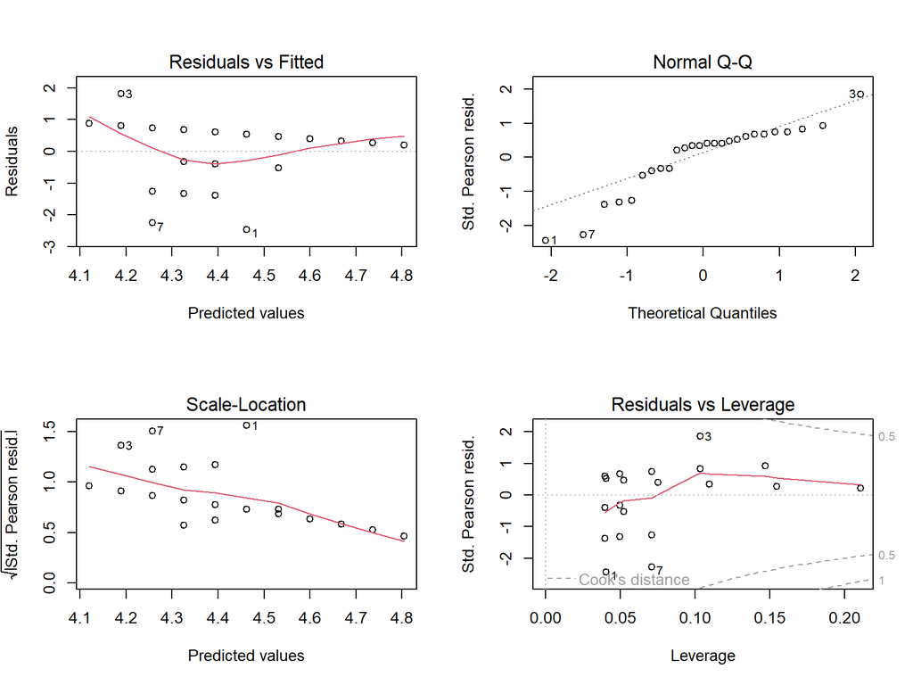

```r
par(mfrow=c(2,2))
plot(GTMNERRMontheffect)
```

```r
#if month does have an effect, you will likely want to incorporate it into the model. Here, we are
##modeling species richness over time by year

colnames(GTMNERR)
```

[1] “ManagedArea” “yearmonth” “Year” “Month” “speciesrichness”

```r
#first let's plot the richness:
##by yearmonth
png("output/GTMNERR Coastal Wetlands Species Richness Data.png")
par(mfrow=c(1,1))
plot(GTMNERR$yearmonth, GTMNERR$speciesrichness,
     xlab="Year",ylab="# of species",main="GTMNERR Coastal Wetlands Species Richness by Month & Year")
plot(GTMNERR$Year, GTMNERR$speciesrichness,
     xlab="Year",ylab="# of species",main="GTMNERR Coastal Wetlands Species Richness by Year")
dev.off()
```

png 2

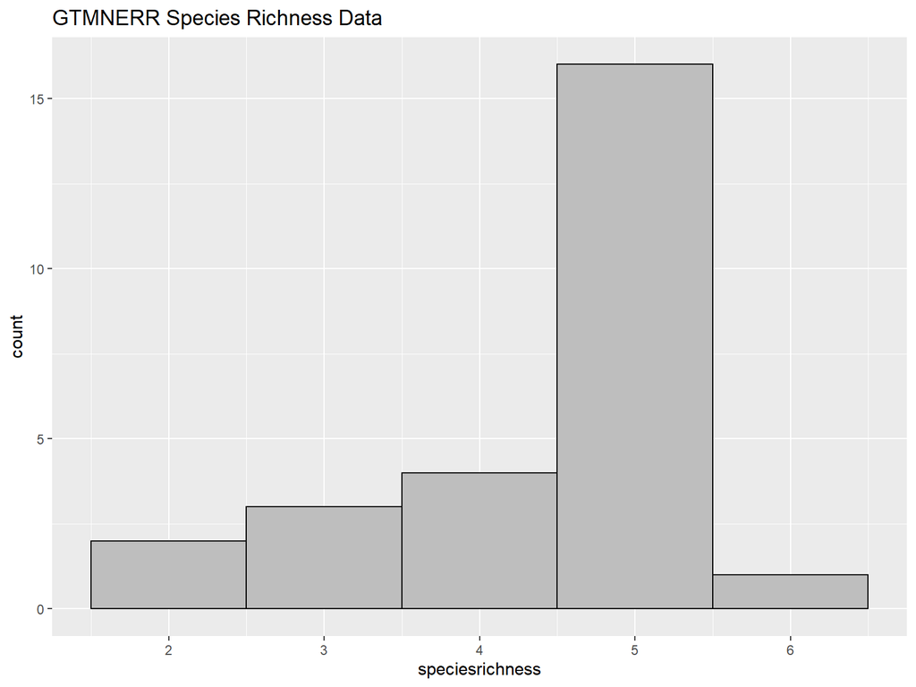

```r
#histogram of data
library(ggplot2)
par(mfrow=c(1,1))
ggplot(GTMNERR, aes(x=speciesrichness)) +
      geom_histogram(binwidth=1,color="black", fill="grey")+
      ggtitle("GTMNERR Species Richness Data")
```

```r
ggsave("output/GTMNERR Spp Richness Histogram.png")

#Run the glm- below are samples to run it first by year, then by yearmonth.
#Following that are sample lines of code to run the same analyses with different families. We are plotting the first example,
#but you will want to run each family and compare the model outputs.
#YEAR
GTMNERRmodelYear=glm(GTMNERR$speciesrichness~GTMNERR$Year)
summary(GTMNERRmodelYear)
```

Call: glm(formula = GTMNERR$speciesrichness ~ GTMNERR$Year)

Deviance Residuals: Min 1Q Median 3Q Max  
-2.0848 -0.5678 0.1822 0.6220 2.2085

Coefficients: Estimate Std. Error t value Pr(>|t|)  
(Intercept) -586.1678 289.1236 -2.027 0.0539 . GTMNERR$Year 0.2932 0.1435 2.043 0.0522 . — Signif. codes: 0 ‘**’ 0.001 ’**’ 0.01 ’’ 0.05 ‘.’ 0.1 ’ ’ 1

(Dispersion parameter for gaussian family taken to be 0.9351695)

```
Null deviance: 26.346  on 25  degrees of freedom
```

Residual deviance: 22.444 on 24 degrees of freedom AIC: 75.961

Number of Fisher Scoring iterations: 2

```r
png("output/GTMNERR Coastal Wetlands Species Richness by Year_Diagnostics.png")
par(mfrow=c(2,2))
plot(GTMNERRmodelYear)
dev.off()
```

png 2

```r
#PLOT the model
GTMNERRmodel<-ggplot(GTMNERR, aes(x = Year, y = speciesrichness) ) +
      geom_point() +
      geom_smooth(method = "glm", alpha = .1,se=TRUE,color="darkgreen", fill="green") +
      theme_ipsum() +
      ggtitle("GTMNERR Species Richness by Year Fitted Model")

#export file by clicking #Export on the left and saving as:
#GTMNERR Coastal Wetlands Species Richness by Year_Model fit


#YEARMONTH
#GTMNERRmodelYearmonth=glm(GTMNERR$speciesrichness~GTMNERR$yearmonth)
#summary(GTMNERRmodelYearmonth)

#try other families
#GTMNERR3=glm(GTMNERR$speciesrichness~GTMNERR$Year,family=poisson)
#summary(NGTMNERR3)

#GTMNERR4=glm(GTMNERR$speciesrichness~GTMNERR$Year,family=Gamma)
#summary(GTMNERR4)

#GTMNERR5=glm(GTMNERR$speciesrichness~GTMNERR$Year,family=inverse.gaussian)
#summary(GTMNERR5)

#############################################

#Next MA
#start with just one Managed Area: GuanaRiverMarsh
unique(wetlandsspprichReg$ManagedArea)
```

[1] “Guana River Marsh” “Guana Tolomato Matanzas NERR”

```r
GuanaRiverMarsh<-
      wetlandsspprichReg%>%
      filter(ManagedArea=="Guana River Marsh")
colnames(GuanaRiverMarsh)
```

[1] “ManagedArea” “yearmonth” “Year” “Month” “speciesrichness”

```r
#
#See if Month influences spp richness
GuanaRiverMarshMontheffect=glm(GuanaRiverMarsh$speciesrichness~GuanaRiverMarsh$Month)
summary(GuanaRiverMarshMontheffect)
```

Call: glm(formula = GuanaRiverMarsh$speciesrichness ~ GuanaRiverMarsh$Month)

Deviance Residuals: Min 1Q Median 3Q Max  
-0.82231 -0.17713 0.00028 0.11855 0.82287

Coefficients: Estimate Std. Error t value Pr(>|t|)  
(Intercept) 2.47281 0.20812 11.881 0.00000000117 ** *GuanaRiverMarsh$Month -0.05914 0.02679 -2.208 0.0413*  
— Signif. codes: 0 ‘**’ 0.001 ’**’ 0.01 ’’ 0.05 ‘.’ 0.1 ’ ’ 1

(Dispersion parameter for gaussian family taken to be 0.1347435)

```
Null deviance: 2.9474  on 18  degrees of freedom
```

Residual deviance: 2.2906 on 17 degrees of freedom AIC: 19.723

Number of Fisher Scoring iterations: 2

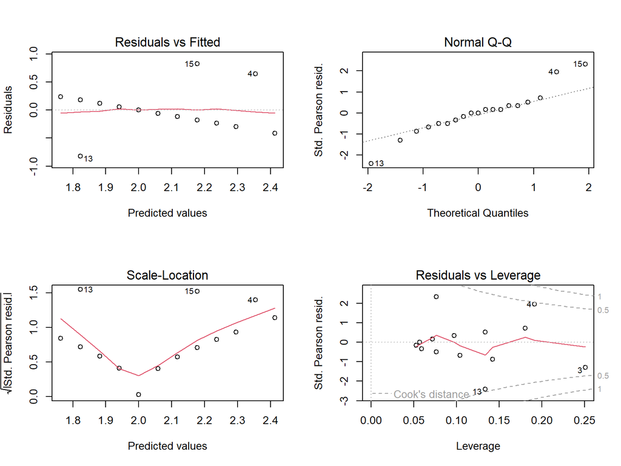

```r
par(mfrow=c(2,2))
plot(GuanaRiverMarshMontheffect)
```

```r
#if month does have an effect, you will likely want to incorporate it into the model. Here, we are
##modeling species richness over time by year

colnames(GuanaRiverMarsh)
```

[1] “ManagedArea” “yearmonth” “Year” “Month” “speciesrichness”

```r
#first let's plot the richness:
##by yearmonth
png("output/GuanaRiverMarsh Coastal Wetlands Species Richness Data.png")
par(mfrow=c(1,1))
plot(GuanaRiverMarsh$yearmonth, GuanaRiverMarsh$speciesrichness,
     xlab="Year",ylab="# of species",main="GuanaRiverMarsh Coastal Wetlands Species Richness by Month & Year")
plot(GuanaRiverMarsh$Year, GuanaRiverMarsh$speciesrichness,
     xlab="Year",ylab="# of species",main="GuanaRiverMarsh Coastal Wetlands Species Richness by Year")
dev.off()
```

png 2

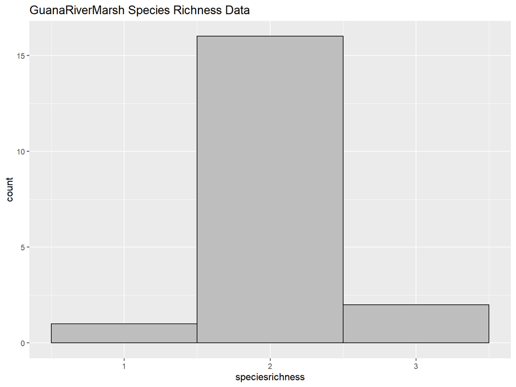

```r
#histogram of data
library(ggplot2)
par(mfrow=c(1,1))
ggplot(GuanaRiverMarsh, aes(x=speciesrichness)) +
      geom_histogram(binwidth=1,color="black", fill="grey")+
      ggtitle("GuanaRiverMarsh Species Richness Data")
```

```r
ggsave("output/GuanaRiverMarsh Spp Richness Histogram.png")

#Run the glm- below are samples to run it first by year, then by yearmonth.
#Following that are sample lines of code to run the same analyses with different families. We are plotting the first example,
#but you will want to run each family and compare the model outputs.
#YEAR
GuanaRiverMarshmodelYear=glm(GuanaRiverMarsh$speciesrichness~GuanaRiverMarsh$Year)
summary(GuanaRiverMarshmodelYear)
```

Call: glm(formula = GuanaRiverMarsh$speciesrichness ~ GuanaRiverMarsh$Year)

Deviance Residuals: Min 1Q Median 3Q Max  
-1.04286 -0.05833 -0.04286 -0.04286 0.95714

Coefficients: Estimate Std. Error t value Pr(>|t|) (Intercept) -60.29524 177.74877 -0.339 0.739 GuanaRiverMarsh$Year 0.03095 0.08824 0.351 0.730

(Dispersion parameter for gaussian family taken to be 0.1721289)

```
Null deviance: 2.9474  on 18  degrees of freedom
```

Residual deviance: 2.9262 on 17 degrees of freedom AIC: 24.376

Number of Fisher Scoring iterations: 2

```r
png("output/GuanaRiverMarsh Coastal Wetlands Species Richness by Year_Diagnostics.png")
par(mfrow=c(2,2))
plot(GuanaRiverMarshmodelYear)
dev.off()
```

png 2

```r
#PLOT the model
GuanaRiverMarshmodel<-ggplot(GuanaRiverMarsh, aes(x = Year, y = speciesrichness) ) +
      geom_point() +
      geom_smooth(method = "glm", alpha = .1,se=TRUE,color="darkgreen", fill="green") +
      theme_ipsum() +
      ggtitle("GuanaRiverMarsh Species Richness by Year Fitted Model")
```